# Week 10 Homework

Author

Anna Hiltner Nouzeilles

# Marijuana Legalization and Sex

## Contingency Table

```
        Support Legalization
Sex      Oppose Support
  Female    191     415
  Male      144     372
```

## Visualization

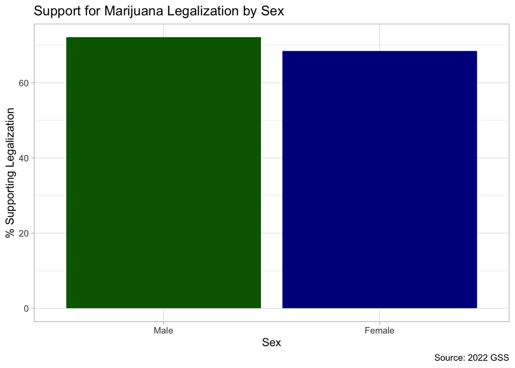

grass = Outcome Y

sex = Predictor X

X = 1 is male

X = 0 is female

## Difference in Probability Regression

```r
mytidy <- function(x) {
  broom::tidy(x) |>
    select(term, estimate, std.error)
}

mod1_sgrass <- lm(grass ~ sex,
            data = sgrass)

mytidy(mod1_sgrass)
```

```
# A tibble: 2 × 3
  term        estimate std.error
  <chr>          <dbl>     <dbl>
1 (Intercept)   0.685     0.0186
2 sex           0.0361    0.0274
```

Males are 3.61 percentage points more likely to support marijuana legalization than females. However, the p-value of .188 is above alpha 0.05 which means we fail to reject the null hypothesis.

## Risk Ratio Regression

```r
mod2_sgrass <- glm(grass ~ sex,
            data = sgrass,
            family = binomial(link = "log"))

mytidy(mod2_sgrass)
```

```
# A tibble: 2 × 3
  term        estimate std.error
  <chr>          <dbl>     <dbl>
1 (Intercept)  -0.379     0.0276
2 sex           0.0514    0.0389
```

```r
exp(0.05139)
```

```
[1] 1.052733
```

The Risk Ratio is 1.0527. Males are 5.3% more likely to support marijuana legalization compared to females. However, the p-value of 0.186 is higher than our alpha of 0.05 which means we fail to reject the null hypothesis.

## Log Probability and Risk Ratio

```r
mod3_sgrass <- glm(grass ~ sex,
            data = sgrass,
            family = binomial(link = "log"))
mytidy(mod3_sgrass)
```

```
# A tibble: 2 × 3
  term        estimate std.error
  <chr>          <dbl>     <dbl>
1 (Intercept)  -0.379     0.0276
2 sex           0.0514    0.0389
```

### Log Probability

$\alpha$ = -0.38

### Log Risk Ratio

$\beta$ = 0.051

## Log Odds

```r
mod4_sgrass <- glm(grass ~ sex,
            data = sgrass,
            family = binomial(link = "logit"))

mytidy(mod4_sgrass)
```

```
# A tibble: 2 × 3
  term        estimate std.error
  <chr>          <dbl>     <dbl>
1 (Intercept)    0.776    0.0874
2 sex            0.173    0.131
```

$$\log\left(\frac{P(grass = 1)}{1 - P(grass = 1)}\right)$$

The log odds that grass = 1 when sex = 0 is $\alpha$ = 0.77601

For sex = 1, the log odds that grass = 1 is 0.77601 + 0.17308 = 0.94909

## Log Odds Ratio

$$\beta = \log \left[ \frac{P(grass = 1 \mid sex=1)}{1 - P(grass = 1 \mid sex = 1)} \right] - \log \left[ \frac{P(grass = 1 \mid sex=0)}{1 - P(grass = 1 \mid sex=0)} \right]$$

$\beta$ = 0.17308 The exponentiated beta is 1.1889

The odds of supporting marijuana are 1.19 times greater for males than for females.

```
[1] 1.188961
```

# Degree Attainment and Abortion

## Contingency Table

```r
degree_abany <- gss2022 |>
  select(abany, degree) |>
  drop_na() |>
  mutate(abany = if_else(abany == 1, 1, 0)) |>
  mutate(grad = if_else(degree == 4, 1, 0)) |>
  select(abany, grad)

degree_abany_table <- table(degree_abany$abany, degree_abany$grad)

dimnames(degree_abany_table) <- list(
  "Abortion" = c("Oppose", "Support"),
  "Degree Attainment" = c("Non-Graduate", "Graduate")
)

print(degree_abany_table)
```

```
         Degree Attainment
Abortion  Non-Graduate Graduate
  Oppose           488       58
  Support          658      141
```

## Visualization

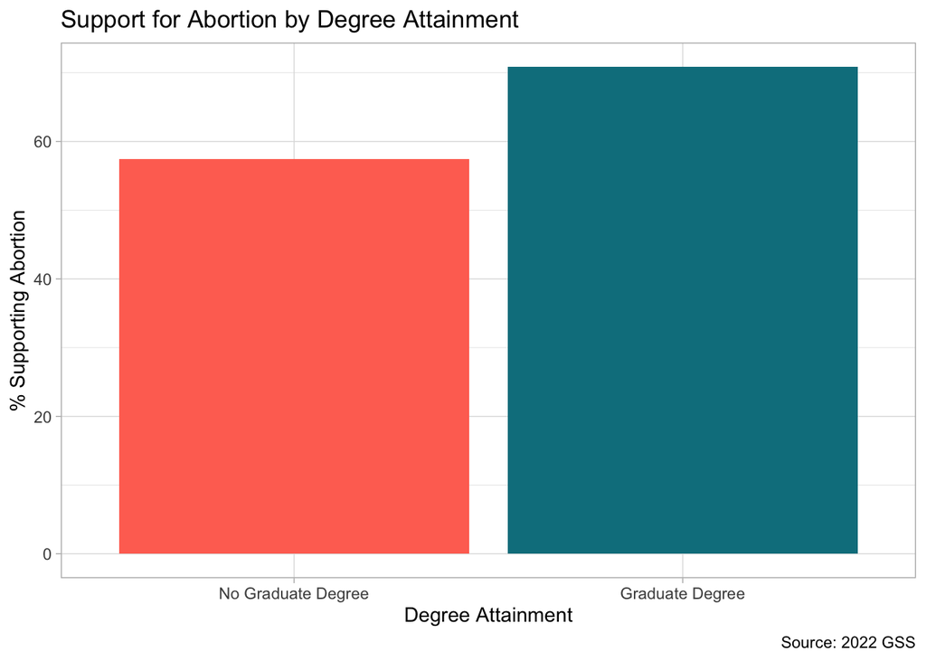

## Difference in Probability Regression

```r
mod1_degree_abany <- lm(abany ~ grad,
            data = degree_abany)

mytidy(mod1_degree_abany)
```

```
# A tibble: 2 × 3
  term        estimate std.error
  <chr>          <dbl>     <dbl>
1 (Intercept)    0.574    0.0144
2 grad           0.134    0.0376
```

Grads are 13.4% percentage points more likely to support abortion than non-graduates.

## Risk Ratio Regression

```r
mod2_degree_abany <- glm(abany ~ grad,
            data = degree_abany,
            family = binomial(link = "log"))

mytidy(mod2_degree_abany)
```

```
# A tibble: 2 × 3
  term        estimate std.error
  <chr>          <dbl>     <dbl>
1 (Intercept)   -0.555    0.0254
2 grad           0.210    0.0521
```

```r
exp(0.210283)
```

```
[1] 1.234027
```

The Risk Ratio is 1.234. Those with a grad degree are are 23% more likely to support abortion compared to those without a grad degree.

## Log Probability and Risk Ratio

```r
mod3_degree_abany <- glm(abany ~ grad,
            data = degree_abany,
            family = binomial(link = "log"))
mytidy(mod3_degree_abany)
```

```
# A tibble: 2 × 3
  term        estimate std.error
  <chr>          <dbl>     <dbl>
1 (Intercept)   -0.555    0.0254
2 grad           0.210    0.0521
```

### Log Probability

$\alpha$ = -0.555

### Log Risk Ratio

$\beta$ = 0.21

## Log Odds

```r
mod4_degree_abany <- glm(abany ~ grad,
            data = degree_abany,
            family = binomial(link = "logit"))

mytidy(mod4_degree_abany)
```

```
# A tibble: 2 × 3
  term        estimate std.error
  <chr>          <dbl>     <dbl>
1 (Intercept)    0.299    0.0597
2 grad           0.589    0.167
```

```r
exp(.59)
```

```
[1] 1.803988
```

$$\log\left(\frac{P(abany = 1)}{1 - P(abany = 1)}\right)$$

The log odds that abany = 1 when grad = 0 is $\alpha$ = .299

For grad = 1, the log odds that abany = 1 is 0.299 + 0.589 = 0.888

## Log Odds Ratio

$$\beta = \log \left[ \frac{P(abany = 1 \mid grad=1)}{1 - P(abany = 1 \mid grad = 1)} \right] - \log \left[ \frac{P(abany = 1 \mid grad=0)}{1 - P(abany = 1 \mid grad=0)} \right]$$

$\beta$ = 0.59 The exponentiated beta is 1.8

The odds of supporting abortion are 1.8 times greater for those with a graduate degree than those without one.

# Voted for Biden and Marijuana Legalization

## Contingency Table

```
         Marijuana Legalization
Biden     Oppose Support
  No Vote    145     182
  Vote        81     336
```

## Visualization

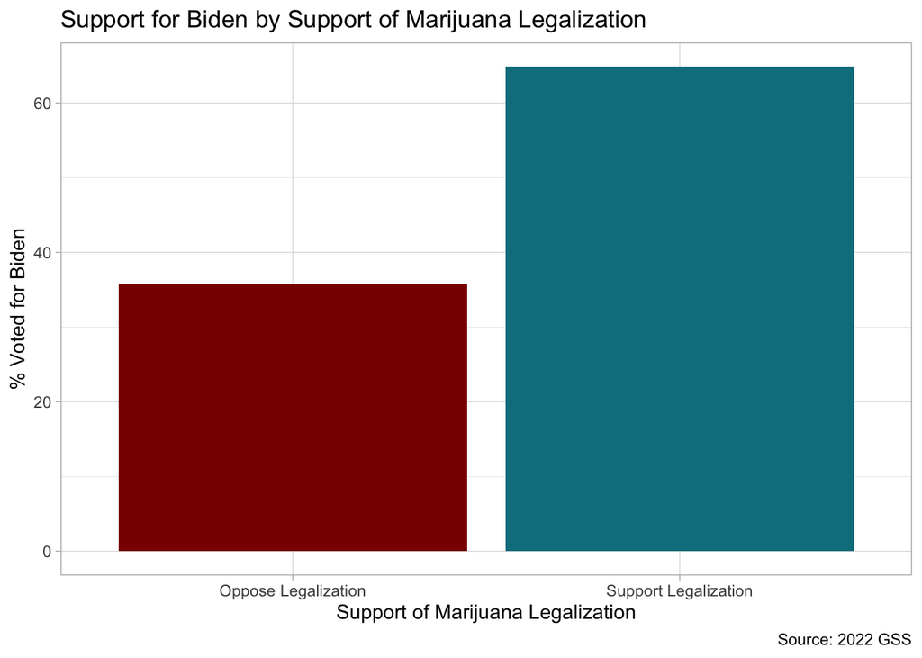

## Difference in Probability Regression

```r
mod1_biden_grass <- lm(biden ~ grass,
            data = biden_grass)

mytidy(mod1_biden_grass)
```

```
# A tibble: 2 × 3
  term        estimate std.error
  <chr>          <dbl>     <dbl>
1 (Intercept)    0.358    0.0318
2 grass          0.290    0.0382
```

Marijuana legalization supporters are 29 percentage points more likely to have voted for Biden than those opposed to marijuana legalization.

## Risk Ratio Regression

```r
mod2_biden_grass <- glm(biden ~ grass,
            data = biden_grass,
            family = binomial(link = "log"))

mytidy(mod2_biden_grass)
```

```
# A tibble: 2 × 3
  term        estimate std.error
  <chr>          <dbl>     <dbl>
1 (Intercept)   -1.03     0.0890
2 grass          0.593    0.0947
```

```r
exp(0.5932218)
```

```
[1] 1.80981
```

The Risk Ratio is 1.81. Marijuana legalization supporters are 81% more likely to have voted for Biden than those who oppose marijuana legalization.

## Log Probability and Risk Ratio

```r
mod3_biden_grass <- glm(biden ~ grass,
            data = biden_grass,
            family = binomial(link = "log"))
mytidy(mod3_biden_grass)
```

```
# A tibble: 2 × 3
  term        estimate std.error
  <chr>          <dbl>     <dbl>
1 (Intercept)   -1.03     0.0890
2 grass          0.593    0.0947
```

### Log Probability

$\alpha$ = -1.03

### Log Risk Ratio

$\beta$ = 0.593

## Log Odds

```r
mod4_biden_grass <- glm(biden ~ grass,
            data = biden_grass,
            family = binomial(link = "logit"))

mytidy(mod4_biden_grass)
```

```
# A tibble: 2 × 3
  term        estimate std.error
  <chr>          <dbl>     <dbl>
1 (Intercept)   -0.582     0.139
2 grass          1.20      0.166
```

$$\log\left(\frac{P(biden = 1)}{1 - P(biden = 1)}\right)$$

## Log Odds Ratio

$\beta$ = 1.2 The exponentiated beta is 3.32

```
[1] 3.320117
```

# Voted for Biden and Degree Attainment

## Contingency Table

```
         Degree Attainment
Biden     Non-Graduate Graduate
  No Vote          957      112
  Vote            1371      357
```

## Visualization

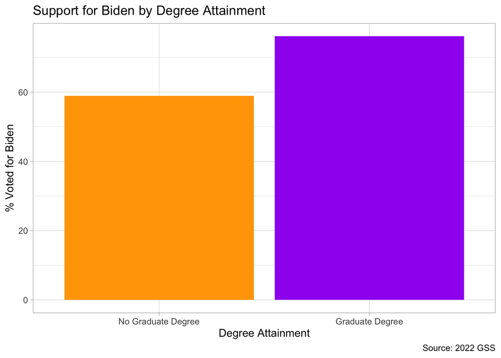

## Difference in Probability Regression

```r
mod1_biden_grad <- lm(biden ~ grad,
            data = biden_grad)

mytidy(mod1_biden_grad)
```

```
# A tibble: 2 × 3
  term        estimate std.error
  <chr>          <dbl>     <dbl>
1 (Intercept)    0.589   0.00999
2 grad           0.172   0.0244
```

Respondents with a graduate degree are 17.2 percentage points more likely to have voted for Biden than those without a graduate degree.

## Risk Ratio Regression

```r
mod2_biden_grad <- glm(biden ~ grad,
            data = biden_grad,
            family = binomial(link = "log"))

mytidy(mod2_biden_grad)
```

```
# A tibble: 2 × 3
  term        estimate std.error
  <chr>          <dbl>     <dbl>
1 (Intercept)   -0.529    0.0173
2 grad           0.257    0.0311
```

```r
exp(0.2566021)
```

```
[1] 1.292531
```

The Risk Ratio is 1.29. Those with a graduate degree are 29.2% more likely to have voted for Biden than those who do not have a graduate degree.

## Log Probability and Risk Ratio

```r
mod3_biden_grad <- glm(biden ~ grad,
            data = biden_grad,
            family = binomial(link = "log"))
mytidy(mod3_biden_grad)
```

```
# A tibble: 2 × 3
  term        estimate std.error
  <chr>          <dbl>     <dbl>
1 (Intercept)   -0.529    0.0173
2 grad           0.257    0.0311
```

### Log Probability

$\alpha$ = -0.53

### Log Risk Ratio

$\beta$ = 0.26

## Log Odds

```r
mod4_biden_grad <- glm(biden ~ grad,
            data = biden_grad,
            family = binomial(link = "logit"))

mytidy(mod4_biden_grad)
```

```
# A tibble: 2 × 3
  term        estimate std.error
  <chr>          <dbl>     <dbl>
1 (Intercept)    0.359    0.0421
2 grad           0.800    0.116
```

$$\log\left(\frac{P(biden = 1)}{1 - P(biden = 1)}\right)$$

## Log Odds Ratio

$\beta$ = .799 The exponentiated beta is 2.22

```
[1] 2.223316
```